# My final Project

worada sirined

8 July 2020

# R Programing

## library

```r
library(gapminder)
library(tidyverse)
library(ggplot2)
library(dplyr)
library(ggthemes)
```

## Preview data set

```r
head(gapminder)
```

| country | continent | year | lifeExp | pop | gdpPercap |
| --- | --- | --- | --- | --- | --- |
| Afghanistan | Asia | 1952 | 28.801 | 8425333 | 779.4453 |
| Afghanistan | Asia | 1957 | 30.332 | 9240934 | 820.8530 |
| Afghanistan | Asia | 1962 | 31.997 | 10267083 | 853.1007 |
| Afghanistan | Asia | 1967 | 34.020 | 11537966 | 836.1971 |
| Afghanistan | Asia | 1972 | 36.088 | 13079460 | 739.9811 |
| Afghanistan | Asia | 1977 | 38.438 | 14880372 | 786.1134 |

## Summary Statistics

- ข้อมูลสะอาด ไม่มีmissing values
- Africa มีอายุสูงสุด 76.4 ปี อายุต่ำสุด 23.6 ปี ค่าเฉลี่ยอายุ เท่ากับ 48.9 ปี มีค่าส่วนเบี่ยงเบนมาตรฐาน 9.15
- Americas มีอายุสูงสุด 80.7 ปี อายุต่ำสุด 37.6 ปี ค่าเฉลี่ยอายุ เท่ากับ 64.7 ปี มีค่าส่วนเบี่ยงเบนมาตรฐาน 9.35
- Asia มีอายุสูงสุด 82.6 ปี อายุต่ำสุด 28.8 ปี ค่าเฉลี่ยอายุ เท่ากับ 60.1 ปี มีค่าส่วนเบี่ยงเบนมาตรฐาน 11.9
- Europe มีอายุสูงสุด 81.8 ปี อายุต่ำสุด 43.6 ปี ค่าเฉลี่ยอายุ เท่ากับ 71.9 ปี มีค่าส่วนเบี่ยงเบนมาตรฐาน 5.43
- Oceaniaมีอายุสูงสุด 81.2 ปี อายุต่ำสุด 69.1 ปี ค่าเฉลี่ยอายุ เท่ากับ 74.3 ปี มีค่าส่วนเบี่ยงเบนมาตรฐาน 3.80
- ค่าที่ต่ำที่สุดใน คอลัม lifeExp คือ 23.60
- ค่าที่สูงที่สุดใน คอลัม lifeExp คือ 82.60
- ค่าที่กลางใน คอลัม lifeExp คือ 60.71
- ค่าเฉลี่ยของคอลัม lifeExp คือ 59.47

```r
gapminder %>%
  group_by(continent) %>%
  summarise(max_lifeExp = max(lifeExp),
            min_lifeExp = min(lifeExp),
            avg_lifeExp = sum(lifeExp)/length(lifeExp),
            sd_lifeExp = sd(lifeExp),
            .groups = 'drop')
```

| continent | max_lifeExp | min_lifeExp | avg_lifeExp | sd_lifeExp |
| --- | --- | --- | --- | --- |
| Africa | 76.442 | 23.599 | 48.86533 | 9.150210 |
| Americas | 80.653 | 37.579 | 64.65874 | 9.345088 |
| Asia | 82.603 | 28.801 | 60.06490 | 11.864532 |
| Europe | 81.757 | 43.585 | 71.90369 | 5.433178 |
| Oceania | 81.235 | 69.120 | 74.32621 | 3.795611 |

```r
gp <- gapminder[, c("lifeExp", "pop", "gdpPercap")]
summary(gp)
```

```
    lifeExp           pop              gdpPercap
 Min.   :23.60   Min.   :6.001e+04   Min.   :   241.2
 1st Qu.:48.20   1st Qu.:2.794e+06   1st Qu.:  1202.1
 Median :60.71   Median :7.024e+06   Median :  3531.8
 Mean   :59.47   Mean   :2.960e+07   Mean   :  7215.3
 3rd Qu.:70.85   3rd Qu.:1.959e+07   3rd Qu.:  9325.5
 Max.   :82.60   Max.   :1.319e+09   Max.   :113523.1
```

### question จัดอับดับทวีปที่มี ค่าเฉลี่ยอายุรวมสูงสุดในช่วง 1952-1972

## Data Wrangling

```r
world_age %>% select(continent:lifeExp) %>%
  filter (year %in% c(1952:1972)) %>%
  group_by(continent) %>%
  summarise( lifeExp = sum(lifeExp)/length(lifeExp),
             .groups = 'drop') %>%
  arrange(desc(lifeExp))
```

| continent | lifeExp |
| --- | --- |
| Oceania | 70.77100 |
| Europe | 68.03269 |
| Americas | 58.08894 |
| Asia | 51.83581 |
| Africa | 43.30135 |

##ค่าเฉลี่ยอายุในช่วง 1952-1972 ของแต่ละทวีป

```r
world_age %>% select(continent:lifeExp) %>%
  filter (year %in% c(1952:1972)) %>%
  group_by(continent,year) %>%
  summarise( lifeExp = sum(lifeExp)/length(lifeExp),
             .groups = 'drop') %>%
  arrange(desc(lifeExp))
```

| continent | year | lifeExp |
| --- | --- | --- |
| Oceania | 1972 | 71.91000 |
| Oceania | 1967 | 71.31000 |
| Oceania | 1962 | 71.08500 |
| Europe | 1972 | 70.77503 |
| Oceania | 1957 | 70.29500 |
| Europe | 1967 | 69.73760 |
| Oceania | 1952 | 69.25500 |
| Europe | 1962 | 68.53923 |
| Europe | 1957 | 66.70307 |
| Europe | 1952 | 64.40850 |

[output cut: 15 more lines]

## long to wide format

```r
yaer_continent_age %>%
  spread(key = year,
         value = lifeExp)
```

| continent | 1952 | 1957 | 1962 | 1967 | 1972 |
| --- | --- | --- | --- | --- | --- |
| Africa | 39.13550 | 41.26635 | 43.31944 | 45.33454 | 47.45094 |
| Americas | 53.27984 | 55.96028 | 58.39876 | 60.41092 | 62.39492 |
| Asia | 46.31439 | 49.31854 | 51.56322 | 54.66364 | 57.31927 |
| Europe | 64.40850 | 66.70307 | 68.53923 | 69.73760 | 70.77503 |
| Oceania | 69.25500 | 70.29500 | 71.08500 | 71.31000 | 71.91000 |

## Data Visualization

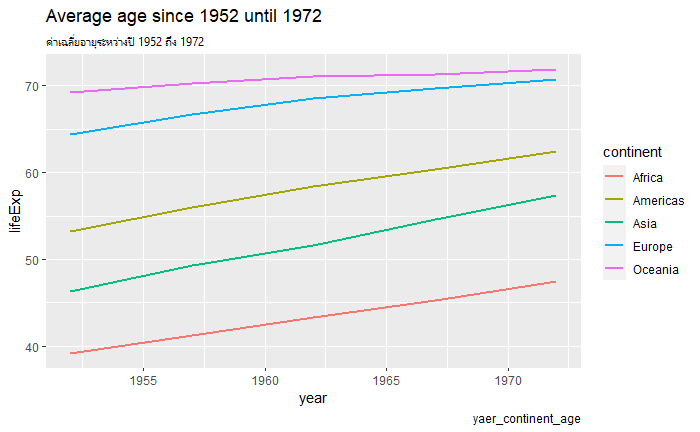

```r
ggplot(yaer_continent_age, aes(year ,lifeExp ,
                                      color=continent)) +
       geom_line(size = 0.8)+
       labs(title = "Average age since 1952 until 1972",
            x = "year",
            y = "lifeExp",
            subtitle = "ค่าเฉลี่ยอายุระหว่างปี 1952 ถึง 1972",
            caption = "yaer_continent_age")
```

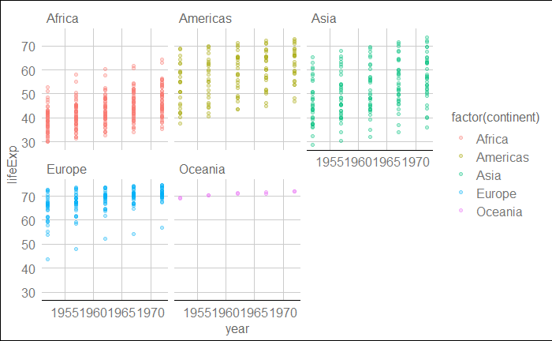

```r
ggplot(world_age , aes ( year , lifeExp,color = factor(continent ))) +
  geom_point(alpha = 0.3)+
  facet_wrap(~ continent)+
  theme_gdocs()
```

## conclusion

1. ข้อมูลชุด continent_age
- ทำให้เราทราบ ค่าเฉลี่ยอายุรวมในช่วง ปี 1952 ถึง 1972 ของแต่ละทวีปทั้ง 5ทวีป
- ทราบทวีปที่มีอายุเฉลี่ยรวมสูงที่สุด ในช่วงเวลาดังกล่าว โดยเรียงลำดับจาก ทวีปที่มีค่าเฉลี่ยอายุสูงที่สุด ไปหา ค่าเฉลี่ยอายุต่ำสุด
2. ข้อมูลชุด yaer_continent_age
- ทำให้ทราบ ค่าเฉลี่ยในแต่ละปี ของทวีปต่างๆ ในช่วง ปี1952 ถึง 1972
- ทำให้ทราบ ค่าเฉลี่ยสูงสุด ต่ำสุด ของ ทวีปต่างๆ ในช่วงเวลาดังกล่าง